# Homework 5

Shuhei Kaneko

2022-11-16

### Question 1

First, import packages necessary for this HW.

```r
library(janitor)
library(tidyverse)
library(tidymodels)
library(ggplot2)
library(glmnet)
library(patchwork)
```

```r
pokemon <- read_csv("data/Pokemon.csv")

pokemon <- clean_names(pokemon)
```

By using clean_names function, the variable name # is replaced with number, and name of all the other variables is changed to snake_case. By this arrangement, we will not be stressed out alternative use of upper and lower case letters.

### Question 2

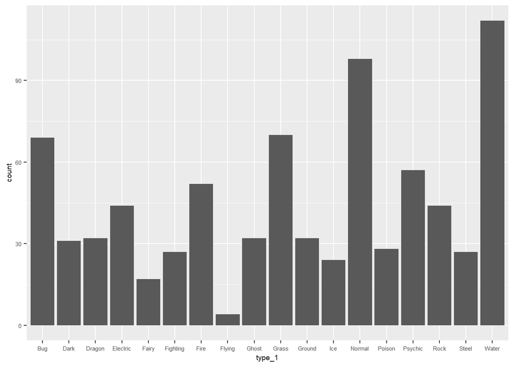

```r
#pokemon <- pokemon %>%
#  mutate(type_1 = as.factor(type_1)) %>%
#  mutate(type_2 = as.factor(type_2))

hist_type_1 <- pokemon %>%
  ggplot(aes(type_1)) +
  geom_bar() +
  theme(text = element_text(size = 7))
plot(hist_type_1)
```

```r
pokemon <- pokemon %>%
  filter(type_1 == "Bug" | type_1 == "Fire" |
        type_1 == "Grass" | type_1 == "Normal" |
        type_1 == "Water" | type_1 == "Psychic")

pokemon <- pokemon %>%
  mutate(legendary = as.factor(legendary)) %>%
  mutate(type_1 = as.factor(type_1)) %>%
  mutate(generation = as.factor(generation))
```

The number of categories is 18. The pokemons whose first type is flying is very few.

### Question 3

```r
# split & stratify the data
set.seed(12345)

pokemon_split <- initial_split(pokemon, prop = 0.80,              strata = type_1)
pokemon_train <- training(pokemon_split)
pokemon_test <- testing(pokemon_split)
```

```r
dim(pokemon_train)
```

```
## [1] 364  13
```

```r
dim(pokemon_test)
```

```
## [1] 94 13
```

```r
#5 fold CV
pokemon_folds <- vfold_cv(pokemon_train, strata = type_1, v = 5)
```

By stratifying the folding data, we can keep distribution of outcome even across the folded datasets. By doing so, the performance of model would not be significantly affected by anomaly distribution of outcome.

### Question 4

```r
pokemon_recipe <- recipe(type_1 ~
                           legendary + generation +
                           sp_atk + attack + speed +
                           defense + hp + sp_def,
                         data = pokemon_train) %>%
  step_novel(all_nominal_predictors()) %>%
  step_dummy(legendary) %>%
  step_dummy(generation) %>%
  step_zv(all_predictors()) %>%
  step_center(all_predictors()) %>%
  step_scale(all_predictors())
```

### Question 5

```r
#Model
elastic_net <- multinom_reg(mixture = tune(), penalty = tune()) %>%
  set_mode("classification") %>%
  set_engine("glmnet")

# Workflow
wkflow <- workflow() %>%
  add_model(elastic_net) %>%
  add_recipe(pokemon_recipe)

# set up the grid
mixture_penalty_grid <- grid_regular(penalty(range = c(-5, 5)),     mixture(range = c(0,1)), levels = 10)

mixture_penalty_grid
```

```
## # A tibble: 100 × 2
##          penalty mixture
##            <dbl>   <dbl>
##  1      0.00001        0
##  2      0.000129       0
##  3      0.00167        0
##  4      0.0215         0
##  5      0.278          0
##  6      3.59           0
##  7     46.4            0
##  8    599.             0
##  9   7743.             0
## 10 100000              0
## # … with 90 more rows
```

Eventually, we fit 10 (mixture grids) * 10 (penalty grids) * 5 (# of fold) = 500 models.

### Question 6

```r
tuning_res <- tune_grid(
  wkflow,
  resamples = pokemon_folds,
  grid = mixture_penalty_grid
)
save(tuning_res,
     file = "tuning_result.rda")
```

```r
load(file = "tuning_result.rda")
```

Run autoplot() function:

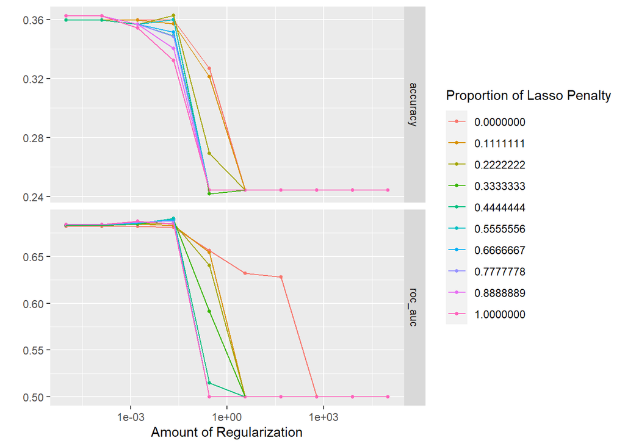

```r
autoplot(tuning_res)
```

Too large penalty produces worse prediction. Regarding mixture, relatively small value yields better prediction result. Best combination was (penalty, mixture) = (0.0215 ,0.444).

### Question 7

```r
best_penalty_mixture <- select_best(tuning_res, metric = "roc_auc")
best_penalty_mixture
```

```
## # A tibble: 1 × 3
##   penalty mixture .config
##     <dbl>   <dbl> <chr>
## 1  0.0215   0.444 Preprocessor1_Model044
```

Fit the model to training set and evaluate the performance in testing set.

### Question 8

```r
elastic_net_final <- finalize_workflow(wkflow, best_penalty_mixture)

#Fit to training set
elasnet_final_fit <- fit(elastic_net_final, data = pokemon_train)

augment(elasnet_final_fit, new_data = pokemon_test) %>%
  accuracy(truth = type_1, estimate = .pred_class)
```

```
## # A tibble: 1 × 3
##   .metric  .estimator .estimate
##   <chr>    <chr>          <dbl>
## 1 accuracy multiclass     0.309
```

```r
pokemon_test <- pokemon_test %>%
  mutate(type_1_bug = if_else(type_1 == "Bug", 0, 1)) %>%
  mutate(type_1_fire = if_else(type_1 == "Fire", 0, 1)) %>%
  mutate(type_1_grass = if_else(type_1 == "Grass", 0, 1)) %>%
  mutate(type_1_normal = if_else(type_1 == "Normal", 0, 1)) %>%
  mutate(type_1_water = if_else(type_1 == "Water", 0, 1)) %>%
  mutate(type_1_psychic = if_else(type_1 == "Psychic", 0, 1)) %>%
  mutate(type_1_bug = as.factor(type_1_bug)) %>%
  mutate(type_1_fire = as.factor(type_1_fire)) %>%
  mutate(type_1_grass = as.factor(type_1_grass)) %>%
  mutate(type_1_normal = as.factor(type_1_normal)) %>%
  mutate(type_1_water = as.factor(type_1_water)) %>%
  mutate(type_1_psychic = as.factor(type_1_psychic))

bug <- augment(elasnet_final_fit, new_data = pokemon_test) %>%
  roc_curve(truth = type_1_bug, estimate = .pred_Bug) %>%
  autoplot()
bug <- bug + ggtitle("Bug")

fire <- augment(elasnet_final_fit, new_data = pokemon_test) %>%
  roc_curve(truth = type_1_fire, estimate = .pred_Fire) %>%
  autoplot()

fire <- fire + ggtitle("Fire")

grass <- augment(elasnet_final_fit, new_data = pokemon_test) %>%
  roc_curve(truth = type_1_grass, estimate = .pred_Grass) %>%
  autoplot()

grass <- grass + ggtitle("Grass")

normal <- augment(elasnet_final_fit, new_data = pokemon_test) %>%
  roc_curve(truth = type_1_normal, estimate = .pred_Normal)%>%
  autoplot()

normal <- normal + ggtitle("Normal")

water <- augment(elasnet_final_fit, new_data = pokemon_test) %>%
  roc_curve(truth = type_1_water, estimate = .pred_Water) %>%
  autoplot(title = "Water")

water <- water + ggtitle("Water")

psychic <- augment(elasnet_final_fit, new_data = pokemon_test) %>%
roc_curve(truth = type_1_psychic,estimate = .pred_Psychic) %>%
  autoplot(title = Psychic)

psychic <- psychic + ggtitle("Psychic")

roc_plots <- bug + fire + grass + normal + water + psychic
```

The comparison of ROC curves:

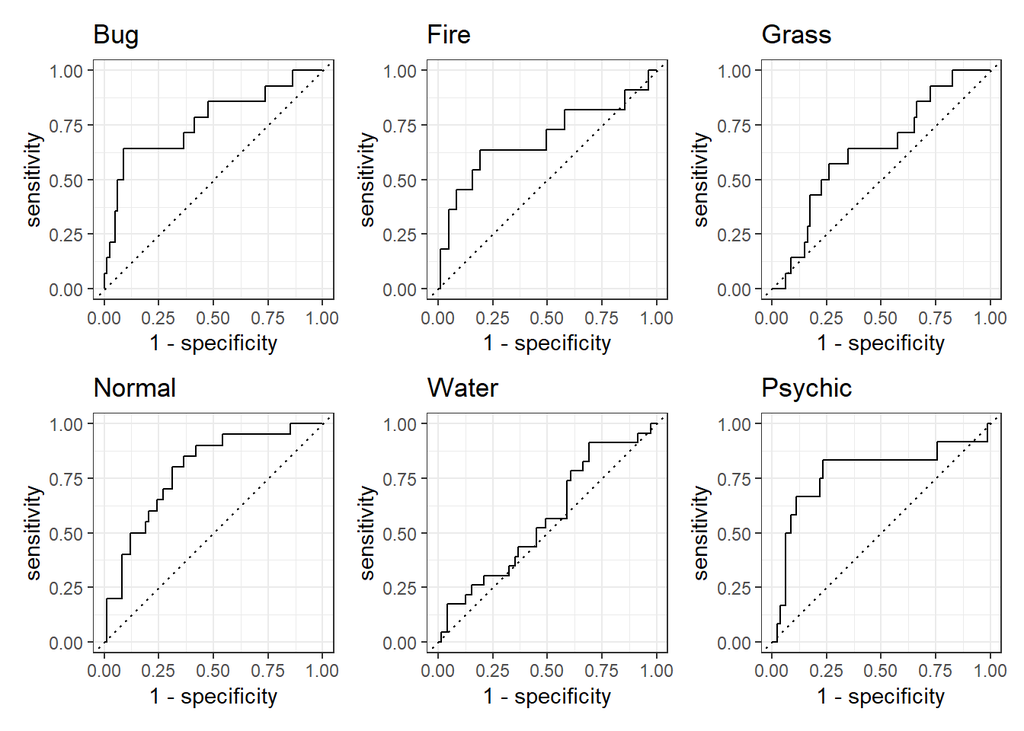

```r
roc_plots
```

Confusion matrix:

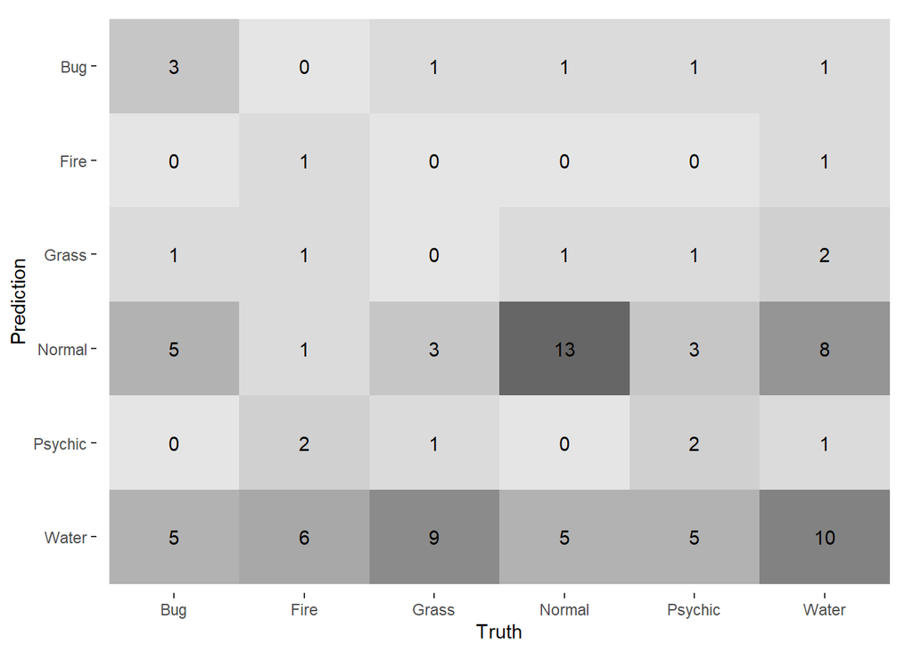

```r
augment(elasnet_final_fit, new_data = pokemon_test) %>%
  conf_mat(truth = type_1, estimate = .pred_class) %>%
  autoplot(type = "heatmap")
```

The prediction for Normal type performs the highest accuracy. Normal-type Pokemon tend to have high HP, which makes easier to predict with a given explanatory variable (as predictor contains hp). On the other hand, the prediction for Grass type is worst. This might be because Grass-type Pokemon do not have outstanding ability values.

### Question 9

```r
missed <- as_tibble(rep(0,464))
made <- as_tibble(rep(1,337))
shots <- bind_rows(missed, made)

#bootstrap
shots_boots <- bootstraps(shots, times = 1000)
boot_res <- map_dbl(
  shots_boots$splits,
  function(x) {
    dat <- as.data.frame(x)$value
    mean(dat == 1)
  }
)

ci99 <- c(quantile(boot_res, 0.005),
          mean(boot_res),
          quantile(boot_res, 0.995))
ci99
```

```
##      0.5%               99.5%
## 0.3720287 0.4209838 0.4681648
```